# vehicle-colour

Michael O’Rourke

April 27, 2018

In simpler times, there were 7 colours. 7 colours that could be remembered using a simple mnemonic. These days there are nearly 2,000 pantone colours and laboratory tests estimate that humans can see approximately 10,000,000 different colours.

Colour can influence our mood, the taste of our food, even our perception of attractiveness. And if it can influence our most primitive of emotions, it should be no surprise that it can influence our buying decisions too. Marketing agencies realised this a long time ago, which is why colour psychology plays such an important part in their campaigns.

The automotive industry is not short of marketeers (or designers). Their influence can be seen in the vast array of colours available to buyers. There are literally thousands of colours available for the exterior of a car. Many with names that could be given to a pop stars first born (‘Lunar sky brown’ and ‘Pepper dust’ are a couple of my current favourites).

With so much variety, and so many different and contrasting tastes, does colour make a difference to the value of a wholesale vehicle?

Internally, our valuation experts often tell us about the importance of colour; “white cars will almost always be worth more” or “steer clear of doom blue vehicles”. And there will always be cases where colour does have an influence, just as there will always be cases where it doesn’t. What we are interested in, is whether colour has a systematic, market level effect on the value of a vehicle. All else being equal, does the colour of the vehicle influence the selling price?

# Does colour effect the value of a used car in UK auctions?

Then come the market influences. Supply and demand for a particular vehicle can change over time. The hot new hatchback can soon become the regular Jerry through no fault of its own (here’s looking at you Fiat 500). It’s not just fashions and tastes that drive demand, market seasonality also plays its part. There is an assumption in the UK that certain vehicle types are worth more at different times of the year. For example, convertibles are thought to sell better before summer than before winter so are worth more. Likewise, 4X4s are expected to sell better as weather conditions worsen in late autumn.

To able to attempt to answer our question, these factors will need to mitigate and controlled for.

### Our data

The data used for this investigation is wholesale sales data from Manheim between the beginning of 2016 and the end of 2017. While this dataset will be smaller than listing data over the same period, it has a couple of major advantages. The first is that it is actual transactional data. We do not need to infer a sale or assume that the selling price is the same the listing price. The second is that it is auction data, so by its nature there is an inherent decision being made by the bidders and buyers about the worth of the vehicle. If a buyer decides that one vehicle is worth more than another, they will usually bid more (subject to budgets, number of other bidders, the buyer’s general mood that day, etc). It is not the same as the decision a consumer makes, where they are presented with a price and they decide whether it is worth it or not.

This gives us a dataset that, once vehicle and market conditions have been controlled for, gives us artefacts about a vehicles relative worth. If colour is an influencer of vehicle price, we should be able to see evidence to support it.

## Controlling for main price drivers

#### Difference in vehicle specification

The industry standard vehicle identifier in the market it the CAP ID/CAP Code. This identifies a vehicle to a high level of granularity. Vehicles with the same CAP ID, have the same manufacturer, range, model, derivative, engine size, fuel type, drive train, transmission, no of doors, and many more technical specifications. They also have relatively short production life-cycles, usually between 3 to 5 years. This makes it an ideal control for vehicle specification. There are limitations to it. Although it categorises vehicles with standard equipment (such as leather seats or navigation systems), it does not control for any optional extras a consumer might have added. These extras aren’t something we can control for within our dataset.

*Only vehicles with the same CAP ID will be compared.*

### Vehicle conditions

#### Age of a vehicle

As a vehicle gets older, it’s value decreases. The rate of depreciation (influence of age on price) also changes as a vehicle gets older.

The graph below shows the relationship between age and wholesale price. We’ve used a random sample of the data to make it easier to see the relationship. Age, measured in months between the registration date and sold date, is along the x-axis (young vehicles towards the left, older vehicles to the right). Sold price, measured in £, is along the y-axis, lower values at the bottom, higher prices at the top. Each dot is a wholesale vehicle sale.

The red line highlights the overall relationship. There is a steep fall in price due to age in the first few months, which softens and stabilises, before gradually levelling off. This means that vehicles lose most of their value in the first couple of years, followed by a period of steady reduction in price (2-12 years), until there isn’t much value left in the vehicle and the price levels off close to 0. It is easy to see why controlling for the age of a vehicle is important.

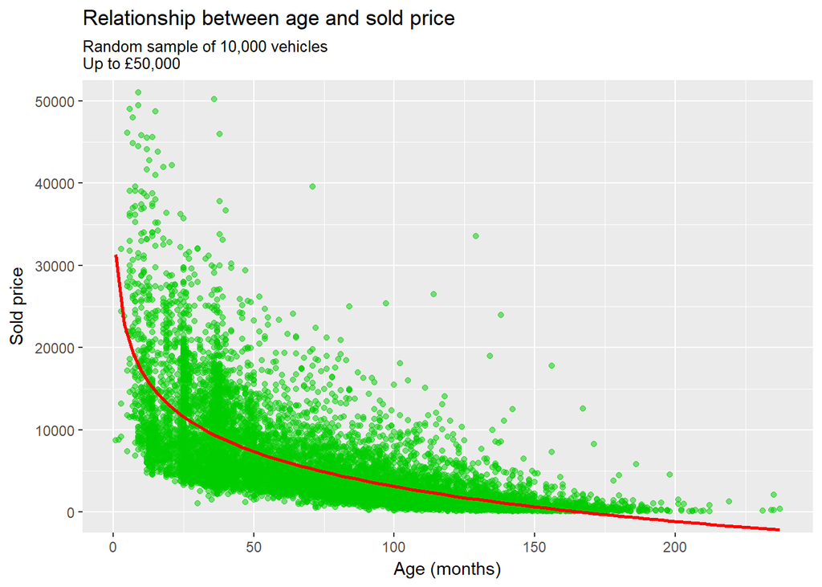

```r
# Create a scatterplot showing age and wholesale price relationship
# Use a sample of the data so that the curve is easier to see
# Limited to £50k for visibilities sake

ggplot(sample_n(data_subset, 10000), aes(age_months, sold_price)) + geom_point(colour = 43, alpha = 0.5) + stat_smooth(method = "lm", formula = y ~ log(x), se = FALSE, colour = 'red') + labs(x = "Age (months)", y = "Sold price") + coord_cartesian(ylim = c(0,50000)) + ggtitle("Relationship between age and sold price", "Random sample of 10,000 vehicles\nUp to £50,000")
```

We can control for age in two ways. We can only compare vehicles with exactly the same age or we can create small cohorts of vehicles with similar ages (e.g. aged between 3 and 6 months). There are pros and cons to both. Using the exact age of a vehicle will allow us to completely control for age but will leave us with few vehicles to compare, especially when we take into consideration other influencers on price (mileage, vehicle condition, etc). Creating small groups would only allow us to control for some of the variance in price due to age but create groups with more vehicles to compare.

*Only vehicles with the same age band will be compared.*

```r
# Create the age cohorts
# Create a sequence of cutoffs. Use unique so that the beginning/end of each sequence is not duplicated
age_cutoffs <- unique(c(seq(3, 12, by = 3), seq(12, 48, by =6),
                        seq(48, 144, by = 12), seq(144, 264, by = 24)))

# Create labels for these cutoffs
age_labels <- as.character(age_cutoffs[1:22]) #  leave of the last cutoff as it is out of range of the data

# Use the cut function to create a new column for the age cohorts
data_subset_with_age_cohorts <- data_subset %>%
  mutate(age_cohort = cut(age_months, breaks = age_cutoffs, labels = age_labels))
```

#### Mileage of a vehicle

The relationship between mileage and sold price is similar to the relationship between age and sold price. As mileage increases, the price decreases. The rate of depreciation also shares the same shape as age; a steep initial drop in price for low mileage vehicles, then a steady, consistent rate of depreciation, before a levelling off towards the high mileages.

The graph below illustrates this relationship. Mileage is measured on the x-axis, low mileages on the left, high mileages to the right. Price is measured on the y-axis, low prices at the bottom, high prices at the top.

As with age, completely controlling for the mileage by exactly matching vehicles on mileage will result in too few vehicles to compare. Instead we’ll group vehicles together based on their relative similarity in mileage. The depreciation rate is most abrupt for lower mileages, so the mileage cohorts will be split into 1,000-mile segments. 10,000 to 30,000 will be split by 5,000-mile segments, 30,000 to 100,000 by 10,000-mile segments and anything above 100,000 miles into cohorts of 20,000-mile segments.

This should allow us to balance specificity with sample size.

*Only vehicles with the same mileage band will be compared.*

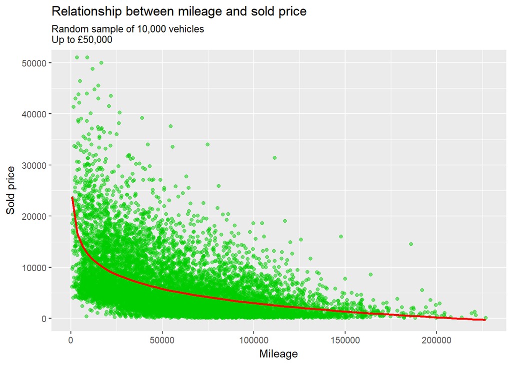

```r
# Create a scatterplot showing age and wholesale price relationship
# Use a sample of the data so that the curve is easier to see
# Limited to £50k for visibilities sake

ggplot(sample_n(data_subset, 10000), aes(mileage, sold_price)) + geom_point(colour = 43, alpha = 0.5) + stat_smooth(method = "lm", formula = y ~ log(x), se = FALSE, colour = 'red') + labs(x = "Mileage", y = "Sold price") + coord_cartesian(ylim = c(0,50000)) + ggtitle("Relationship between mileage and sold price", "Random sample of 10,000 vehicles\nUp to £50,000")
```

```r
mileage_cutoffs <- unique(c(seq(1000, 10000, by = 1000), seq(10000, 30000, by = 5000),
                          seq(30000, 100000, by = 10000), seq(100000, 260000, by = 20000)))

mileage_labels <- as.character(mileage_cutoffs[1:28])


# Create a column which month each sale occured
# This will be used to mitigate the effect of seasonality

# Create function to convert month numbers to equivalent string

convert_months <- function(x){
  ifelse(x == 1, "Jan",
  ifelse(x == 2, "Feb",
  ifelse(x == 3, "Mar",
  ifelse(x == 4, "Apr",
  ifelse(x == 5, "May",
  ifelse(x == 6, "Jun",
  ifelse(x == 7, "Jul",
  ifelse(x == 8, "Aug",
  ifelse(x == 9, "Sep",
  ifelse(x == 10, "Oct",
  ifelse(x == 11, "Nov",
  ifelse(x == 12, "Dec", NA))))))))))))
}

data_subset_cohorts <- data_subset_with_age_cohorts %>%
  mutate(mileage_cohort = cut(mileage, breaks = mileage_cutoffs, labels = mileage_labels),
         month = convert_months(month(date_sold)))
```

#### Condition grade

Age and mileage can be good measures of the usage of the vehicle, but they don’t directly describe the physical condition of a vehicle. A well looked after, 2-year old, 20,000-mile company car is likely to be in better condition than a 2-year old, 20,000-mile family car which has been subjected to three toddlers in the back.

Within the wholesale industry, the physical condition of a vehicle is given a grade. Within Manheim auctions, these scored range from one to five. Well-conditioned vehicles are given a grade of one, poorly conditioned vehicles are given a grade of five. Vehicles that do not meet the criteria to reach grade five are ‘unclassified’. The price penalty between grade one and five can be significant.

*Only vehicles with the same condition grade will be compared.*

In part 2: * How do we control for market levels effects such as inflation and seasonality? * What effect does all of this have on the sample sizes of our comparable vehicles? * How do we translate the near 2,000 colour types into something more usable?

### Market conditions

#### Adjusting for inflation

```r
#CPI data
#Loaded with 1,391 columns. All blank after column 9. Keep only columns I'm interested in (used car CPI)
used_car_cpi_scores <- used_car_cpi_scores %>% select(1,3)
#Rename columns
colnames(used_car_cpi_scores) <- c("title", "used_car_cpi_score")

#CPI dataset contains CPI scores at a annual, quarterly and monthly level. Use monthly
#Example format: 2016 JUL

# Create a column with the CPI data format
data_subset_cohorts_temp <- data_subset_cohorts %>%
  mutate(cpi_date_ref = convert_date_to_cpi_date(date_sold))

# Stop if any of the references are null values
stopifnot(anyNA(data_subset_cohorts_temp$date_sold)== FALSE)

# Join the CPI score data to the vehicle data using the CPI date reference
joined_data_subset <- data_subset_cohorts_temp %>%
  left_join(used_car_cpi_scores, by = c("cpi_date_ref" = "title")) %>%
    mutate(used_car_cpi_score = as.numeric(used_car_cpi_score)) # convert CPI values to numeric

# Set December 2017 as the reference point
# All prices will be adjusted to December 2017
inflation_reference_value <- as.numeric(used_car_cpi_scores %>% filter(title == '2016 DEC') %>% select(used_car_cpi_score))

# Adjust prices
adjusted_price_dataset <- joined_data_subset %>%
  mutate(adjusted_sold_price = round((sold_price/used_car_cpi_score) * inflation_reference_value))

# Histogram showing the effect of the adjustment
# ggplot(adjusted_price_dataset %>%
#          mutate(adjustment_percentage = ((adjusted_sold_price - sold_price)/ sold_price)), # create inflation % change
#        aes(adjustment_percentage)) + geom_histogram(fill = 43, colour = 'grey', alpha = 0.5, binwidth = 0.01) +
#   ggtitle("Distribution of inflation adjustments")
```

### Seasonality

Within the automotive industry, there is an assumption that certain types of vehicles have a higher demand (and therefore higher price) at different times of the year. For example, convertible vehicles are expected to be in higher demand before the summer than after. Likewise, 4x4 vehicles are expected to be in higher demand in the run up to winter.

To take this into effect, sales will be split into cohorts based on the time of the year of their sale. If our dataset was larger, the cohorts could be as granular as months. Unfortunately, when you take into consideration the vehicle type, age, mileage and condition cohorts the number of vehicles available for comparison is likely to be small. For that reason, the cohorts will be at quarter level.

```r
seasonality_dataset <- adjusted_price_dataset %>%
  mutate(seasonality_cohort =  quarter(date_sold))
```

That’s a lot of restrictions, will there be any groups of vehicles with large enough sample sizes to compare against each other?

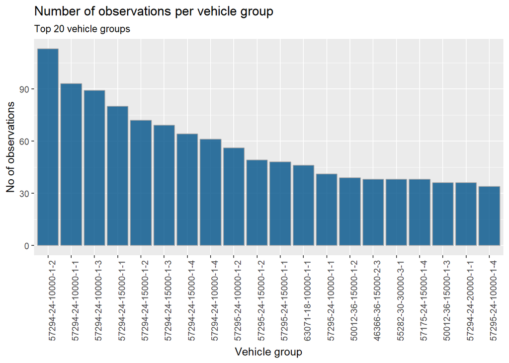

```r
# Create groups with the same age, mileage, condition, cap_id, and seasonality
vehicle_cohort_dataset <- seasonality_dataset %>%
  mutate(vehicle_group = paste(cap_id, age_cohort, mileage_cohort, condition_grade, seasonality_cohort, sep = '-'))

# count how many observations per vehicle group
observations_per_vehicle_group <- vehicle_cohort_dataset %>%
  group_by(vehicle_group) %>%
  summarise(no_of_observations = n()) %>%
  arrange(-no_of_observations)

ggplot(observations_per_vehicle_group %>% top_n(20, no_of_observations),
       aes(reorder(vehicle_group, -no_of_observations), no_of_observations)) +
  geom_col(fill = "#00528A", colour = "#a8aaac", alpha = 0.8) + labs(x = "Vehicle group", y = "No of observations") +
  theme(axis.text.x = element_text(angle = 90, hjust = 1)) +
  ggtitle("Number of observations per vehicle group", "Top 20 vehicle groups")
```

As expected, the sample size of each group is quite small. The largest group has only 113 observations, the 10th has 49 and the 20th has 34. As much as we would like these groups to be larger, the importance of specificity far outweighs the need for large sample sizes.

#### What should be our minimum sample size?

If our cut off is too high, then there are two problems. The most obvious is that it gives us too few groups to compare colours in. The second, is to do with the variety of vehicles. The eagle eyed amongst us would have noticed that the CAP IDs of the top 20 groups are very similar. In fact, 14 of the top 20 groups are Fiesta’s, and 17 are Fords. If we set the cut off too high, we will only be able to compare how colour affects young, low mileage, Ford Fiestas.

If our cut off it too low, then we end up with thousands of groups with a couple of vehicles to compare which is unlikely to tell us anything more than random chance would. Approximately, 99% of all the vehicle groups have 5 or less observations.

### Colours

The simple days of only having to remember the seven colours of the rainbow have long done. In a world where there are nearly 2,000 pantone colours available and even black has different shades. It should be no surprise that there are 1,614 ‘different’ colours of vehicles within our dataset. When designers and marketing teams combine the possibilities are endless. A couple favourites are ‘Lunar sky brown’ and ‘Pepper dust’.

For this analysis, we’ll be going back to basics with our colour descriptions. ‘Moroccan red’ and ‘Tango red metallic’ will be both classified as ‘red’, ‘Sea grey’ and ‘Storm grey’ are both ‘grey’. This will result in some dropped observations, what colour of the rainbow is ‘fashionista’ or ‘vision’.